# Homework 8

KS

2023-03-22

Load in `library(tidyverse)` and `library(ggplot2)`, hidden below.

## Paper

1. Little, S. & Moore, E.B. 1950 “Effect of Prescribed Burns and Shelterwood Cutting on Reproduction of Shortleaf and Pitch Pine”. Northeastern Forest Experiment Station, USFS, Upper Darby, PA.

## Hypothesis

Number of repeat burns increases the number of pine seedlings present.

## Study design, means, and standard deviation

2. 14 1-acre plots; 2 plots left unburned.  
   Other 12, RxFire winter burn applied 1, 2, 3, 4, 5, & 6 times (1940-1946).  
   On half of plots in 1939, overstory oaks thinned via sheterwood. On all plots, pine at 15 seed trees/acre.  
   Remaining oak overstory cut on half of each plot in winter 1946/47. Other half cut winter 1948/49.

As assessed in 1949,  
- unburned plots with 580 seedlings/acre  
- 1 burn : 800 seedlings/acre  
- 2 burn : 1,000 seedlings/acre  
- 3 burn : 1,925 seedlings/acre  
- 4 burn : 1,925 seedlings/acre  
- 5 burn : 2,650 seedlings/acre  
- 6 burn : 2,650 seedlings/acre

Assuming standard deviation is 100 seedlings groups 0-2; 200 seedlings 3-4; 400 seedlings 5-6

## Making random data based on study data

```r
noBurn <- rnorm(n=2, mean = 580, sd = 100)
oneBurn <- rnorm(n=2, mean = 800, sd = 100)
twoBurn <- rnorm(n=2, mean = 1000, sd = 100)
threeBurn <- rnorm(n=2, mean = 1925, sd = 200)
fourBurn <- rnorm(n=2, mean = 1925, sd = 200)
fiveBurn <- rnorm(n=2, mean = 2650, sd = 400)
sixBurn <- rnorm(n=2, mean = 2650, sd = 400)

pineBurn <- data.frame(noBurn,oneBurn,twoBurn,threeBurn,fourBurn,fiveBurn,sixBurn)

pineBurn <- pineBurn %>%
  pivot_longer(cols = noBurn:sixBurn,
               names_to = "treatment",
               values_to = "seedling_counts1")

pineBurn1 <- pineBurn[with(pineBurn, order(treatment)),]
```

4. Create a ANOVA where we compare means

```r
A1 <- aov(pineBurn1$seedling_counts1~pineBurn$treatment)
summary(A1)
```

```
##                    Df  Sum Sq Mean Sq F value Pr(>F)
## pineBurn$treatment  6 7644085 1274014   2.742  0.106
## Residuals           7 3252084  464583
```

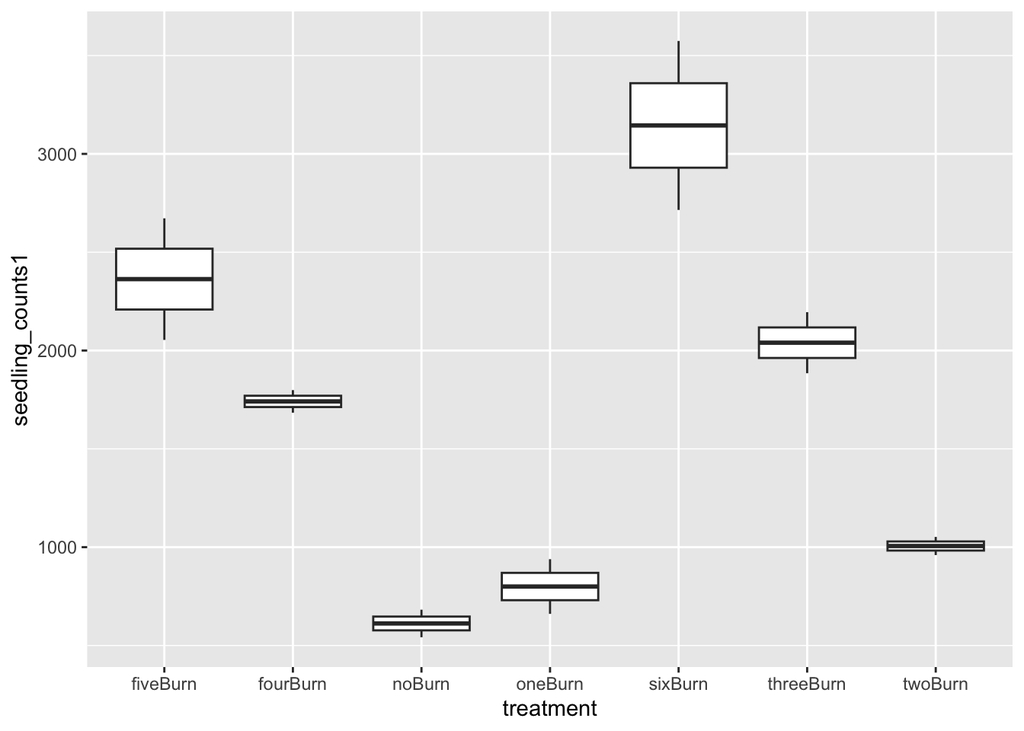

```r
ggplot(pineBurn1, aes(treatment, seedling_counts1)) +
  geom_boxplot()
```

This does not yeild a significant p-value

## Changing the means

6. Changing means for a statistically significant result

```r
noBurn4 <- rnorm(n=2, mean = 570, sd = 100)
oneBurn4 <- rnorm(n=2, mean = 790, sd = 100)
twoBurn4 <- rnorm(n=2, mean = 990, sd = 100)
threeBurn4 <- rnorm(n=2, mean = 1975, sd = 200)
fourBurn4 <- rnorm(n=2, mean = 1975, sd = 200)
fiveBurn4 <- rnorm(n=2, mean = 2725, sd = 400)
sixBurn4 <- rnorm(n=2, mean = 2725, sd = 400)

pineBurn4 <- data.frame(noBurn4,oneBurn4,twoBurn4,threeBurn4,fourBurn4,fiveBurn4,sixBurn4)

pineBurn4 <- pineBurn4 %>%
  pivot_longer(cols = noBurn4:sixBurn4,
               names_to = "treatment",
               values_to = "seedling_counts1")

pineBurn5 <- pineBurn4[with(pineBurn4, order(treatment)),]
```

```r
A3 <- aov(pineBurn4$seedling_counts1~pineBurn4$treatment)
summary(A3)
```

```
##                     Df  Sum Sq Mean Sq F value   Pr(>F)
## pineBurn4$treatment  6 7448114 1241352    58.6 1.25e-05 ***
## Residuals            7  148295   21185
## ---
## Signif. codes:  0 '***' 0.001 '**' 0.01 '*' 0.05 '.' 0.1 ' ' 1
```

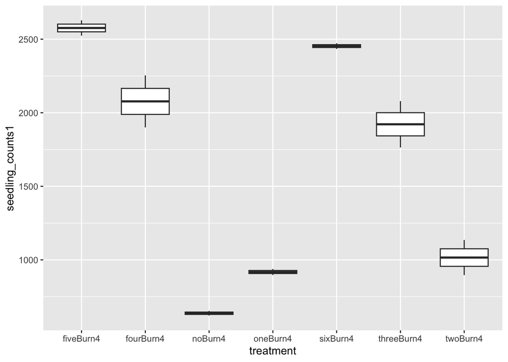

```r
ggplot(pineBurn4, aes(treatment, seedling_counts1)) +
  geom_boxplot()
```

## Increasing the sample size

7. Increasing the sample size for a statistically significant result

```r
noBurn2 <- rnorm(n=3, mean = 580, sd = 100)
oneBurn2 <- rnorm(n=3, mean = 800, sd = 100)
twoBurn2 <- rnorm(n=3, mean = 1000, sd = 100)
threeBurn2 <- rnorm(n=3, mean = 1925, sd = 200)
fourBurn2 <- rnorm(n=3, mean = 1925, sd = 200)
fiveBurn2 <- rnorm(n=3, mean = 2650, sd = 400)
sixBurn2 <- rnorm(n=3, mean = 2650, sd = 400)

pineBurn2 <- data.frame(noBurn2,oneBurn2,twoBurn2,threeBurn2,fourBurn2,fiveBurn2,sixBurn2)

pineBurn2 <- pineBurn2 %>%
  pivot_longer(cols = noBurn2:sixBurn2,
               names_to = "treatment",
               values_to = "seedling_counts1")

pineBurn3 <- pineBurn2[with(pineBurn2, order(treatment)),]
```

While I started by trying n=100, it turns out I only needed one more sample in order to get a significant result. This means 3 samples of each treatment type.

```r
A2 <- aov(pineBurn2$seedling_counts1~pineBurn2$treatment)
summary(A2)
```

```
##                     Df   Sum Sq Mean Sq F value   Pr(>F)
## pineBurn2$treatment  6 12395507 2065918   72.71 9.57e-10 ***
## Residuals           14   397781   28413
## ---
## Signif. codes:  0 '***' 0.001 '**' 0.01 '*' 0.05 '.' 0.1 ' ' 1
```

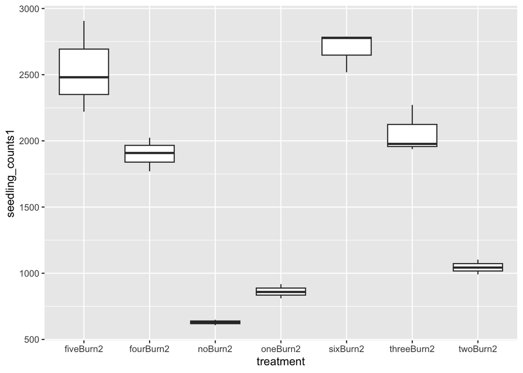

```r
ggplot(pineBurn2, aes(treatment, seedling_counts1)) +
  geom_boxplot()
```

I think it is really interesting that only one more sample of each treatment type needed to be added to yeild a stasticially significant result, as well as a fairly small change in seedling counts. This paper was published by the USFS in 1950 and did not report a p-value.